# When a Digital Shock Hits a Global Firm

Stephen Weymouth

Dean’s Professor

2026-11-16

# On June 27, 2017, the computer screens at Maersk’s headquarters in Copenhagen shut down.

## Your IB Voice

From Ukraine to New Jersey

NotPetya was aimed at Ukraine, yet it stopped Maersk’s terminals from New Jersey to Mumbai. Explain what about the way Maersk was organized caused an attack on one country to halt Maersk’s operations.

**10 minutes** · Individual · Notes permitted

## Competing explanations

Why did an attack on Ukraine stop a global shipping company?

Maersk neglected its security and ran old software.

Maersk ran one network worldwide.

Russia meant to punish any firm that did business in Ukraine.

No firm can defend itself against a government’s military hackers, without very sophisticated defense.

# How did a Ukrainian tax program reach Copenhagen?

## NotPetya spread fast

[figure not shown]

Greenberg, “The Untold Story of NotPetya,” *WIRED*, 2018.

Russian military hackers hid NotPetya, a worm that copies itself from computer to computer, in an update to M.E.Doc, the tax software most Ukrainian firms use.

It used a tool stolen from the NSA and passwords taken from memory to jump between computers.

The ransom note was fake: paying could not restore the files, because NotPetya was built to destroy them.

## Ukraine’s banks and ministries went dark

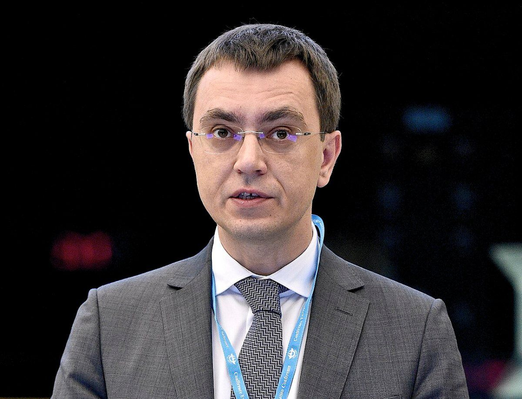

ECAC, [Volodymyr Omelyan, July 2018](https://commons.wikimedia.org/wiki/File:Volodymyr_Omelyan,_July_2018.jpg) · Wikimedia Commons, CC0

The attack hit more than 22 Ukrainian banks, two airports, and almost every federal agency.

One official estimated that it wiped a tenth of the country’s computers.

“The government was dead,” said Volodymyr Omelyan, Ukraine’s minister of infrastructure.

# What did the attack cost Maersk?

# At Maersk’s terminal in Elizabeth, New Jersey, the gate went dead, and hundreds of trucks backed up for miles.

## Seventeen of Maersk’s 76 terminals stopped

NotPetya entered through one computer in Maersk’s office in Odessa that ran M.E.Doc.

The ships’ computers were fine, but the terminals lost the files listing what each ship carried.

*Digital interdependence* means firms, their suppliers and customers, and governments depend on one another through the software and networks they share. One possible result is that a failure in one spreads to the others.

[figure not shown]

Greenberg, “The Untold Story of NotPetya,” *WIRED*, 2018.

# The only clean copy of Maersk’s network directory survived in Ghana, because a power cut had knocked that server offline.

## Maersk approved a security fix and never built it

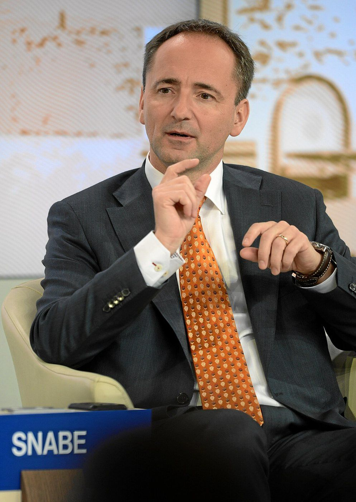

World Economic Forum, [Jim Hagemann Snabe. Maersk Chair](https://commons.wikimedia.org/wiki/File:Jim_Hagemann_Snabe_World_Economic_Forum_2013.jpg), 2013 · Wikimedia Commons, CC BY-SA 2.0

In 2016 Maersk’s IT executives warned that malware in one office could spread across the whole network, and they proposed dividing it into walled-off sections.

The fix had been approved and budgeted, but never implemented.

*Operational resilience* is a firm’s ability to keep working through a failure and recover quickly.

## The attack cost firms far from Ukraine billions

| Firm | Reported loss | Where the loss came from |
| --- | --- | --- |
| **Merck**, U.S. drugmaker | $870 million | Drug and vaccine production stopped |
| **FedEx**, through its Dutch unit TNT Express | $400 million | TNT offices worked on pen and paper, and some data took months to recover |
| **Saint-Gobain**, French maker of building materials | $384 million | Computer systems across the company were down for about two weeks |
| **Maersk**, Danish shipping firm | $300 million | Seventeen terminals stopped; 4,000 servers and 45,000 PCs were needed to be fixed |
| **Mondelez**, U.S. maker of Oreo and Cadbury | $188 million | Shipping and invoicing stopped at the end of the quarter; 24,000 laptops were lost |
| **Reckitt Benckiser**, British maker of Lysol and Durex | $129 million | Output fell at many of its 60 factories, and orders and shipping were disrupted |
| **These six firms** | **about $2.3 billion** |  |
| **All victims**, White House estimate | **more than $10 billion** | Many private firms never reported their losses |

Losses: Greenberg, “The Untold Story of NotPetya,” *WIRED*, 2018. Causes: company filings and statements, 2017.

## Paying for protection

Maersk approved the security fix, but no senior IT manager’s bonus depended on building it. How should a firm make sure someone builds protection against a cyber attack that may never happen?

How is leaving the fix unaddressed a little like a firm using Just in Time?

# Who pays when a cyberattack is an act of war?

## Insurers called NotPetya an act of war, and a court disagreed

Property insurance policies usually exclude damage caused by war. After the U.S. government said Russia’s military launched NotPetya, insurers used that exclusion to refuse claims.

[figure not shown]

Court filings and reporting by *The Record* (2022) and *Cybersecurity Dive* (2024); New Jersey Superior Court, Appellate Division, May 1, 2023.

Since 2023, Lloyd’s of London, a major insurance market, has required its cyber policies to exclude war and state-backed attacks that cripple a country’s government or defenses.

# Cyberattacks are on the rise

## Firms now rank cyber incidents as their top risk

[figure not shown]

Allianz Commercial, [Allianz Risk Barometer](https://commercial.allianz.com/news-and-insights/news/allianz-risk-barometer-2026.html), 2013 to 2026.

Cyber incidents have ranked first among business risks every year since 2022.

In 2026 artificial intelligence rose to second place.

*Cyber risk* is the chance that an attack on a firm’s computers stops its business.

## In 2025 one attack stopped Jaguar Land Rover

The carmaker shut its systems on September 2, 2025, and restarted production in stages from October 8.

More than 5,000 British firms were affected, and the government guaranteed a £1.5 billion loan.

Eight years after NotPetya, one firm’s outage still spread through its suppliers.

[figure not shown]

JLR, [results for the quarter to September 30, 2025](https://media.jlr.com/corporate/news/2025/11/jlr-performance-impacted-challenging-quarter), November 14, 2025.

## Governments are telling households to prepare

| 2026 | Government | What it issued | What households are asked to have |
| --- | --- | --- | --- |
| Aug 14 | France | Updated national guide | A 72-hour kit with water, food, medicine, and a radio |
| Aug 28 | Ireland | New campaign; booklets mailed in November | “An adequate supply” of water, food, and medicine |
| Oct 1 | Belgium | New national guide | A 72-hour kit and a family emergency plan |
| Oct 12 | Netherlands | New phase of its “Think Ahead” campaign | Enough to last 72 hours without power, water, or internet |
| Oct 22 | United Kingdom | “Be Ready,” a three-year campaign | Three days of water and food, plus cash and a radio |
| Nov 2 | Japan | Request from its new disaster agency | Three days of food, water, and toilets, a week if possible |
| Nov 3 | Iceland | New household booklet | Three days of supplies for power cuts and severe weather |
| Nov 3 | European Commission | Guidelines for national governments | Enough to manage at least 72 hours alone |

Government announcements and news reports, August to November 2026.

None of these governments said a specific attack or disaster was coming.

# Spend Maersk’s 2016 security budget

## Choose the protection that would have saved the most

1. **Choose** one protection Maersk could have bought in 2016: dividing the network into sections, offline backups of the domain controllers, patching and replacing old Windows servers, or tying IT bonuses to security.
2. **Diagnose** which stage of the attack it would have stopped: getting in, spreading, or recovering, using one passage from Greenberg.
3. **Estimate** what it would have cost in a normal year against the $250 million to $300 million loss.
4. **Defend** your choice to the person next to you.

**15 minutes** · Individual, then pairs · Reading permitted

## Report out

Which protection would have saved Maersk the most, and why had no one paid for it?

## Closing discussion

Russia reached firms around the world through one country’s tax software. If one government controlled a network that most firms depend on, what could it do with that control?

On Wednesday, we read Farrell and Newman on who controls the networks firms depend on.

## Module 8 takeaways

How do shocks travel through global business?

Firms cut spare stock and capacity to save money, so a delay at one step can stop a whole chain.

A shock travels along the links that make a firm efficient, such as shared ports in 2021 and a shared network in 2017.

Truckers and suppliers bear costs they did not choose, while whoever controls a bottleneck may gain.

Resilience costs money in normal years, so firms underinvest in it until a shock shows its value.